# BEST PRACTICES

Adherence of this **Notebook Analysis** to some of the rules described in:

Ten simple rules for writing and sharing computational analyses in Jupyter Notebooks Adam Rule,Amanda Birmingham,Cristal Zuniga,Ilkay Altintas,Shih-Cheng Huang,Rob Knight,Niema Moshiri,Mai H. Nguyen,Sara Brin Rosenthal,Fernando Pérez,Peter W. Rose Published: July 25, 2019 https://doi.org/10.1371/journal.pcbi.1007007

### **Rule 1** Tell a story for an audience:

This analysis was developed in a way that the computational narrative is cohesive with the comments and explanations. Notes, explanations and interpretations were added in order for the **'Client'** to better understand the conclusions of the analysis.

### **Rule 2** Document the process, not just the results:

This tutorial is splitt into different sections. All initial sections primarely document the datafile, data dictionary and some preliminary exploration of the file. The last visualizations look into the patterns of the data to provide recommendations to the 'Client' about his exercise rutines.

### **Rule 3** Share and explain your data:

In order to follow an structured story flow that is not broken or with pieces that are hard to connect, a table of contents was created. Different types of annotation tags/markdowns were added to improve readability. Additionally, some features like colors were added to improve user engagement. Cell were kept short and susinct so that the user does not loose track of the flow.

### **Rule 8** Share and explain your data:

This code has been uploaded to GitHub.com. This notebook was clearly annotated so that any persont that downloads will be able to replicate results and use this code.

# **Strava File / Visual Exploration:**

#### - for Chris Brooks -

[figure not shown]

**Created by: *Leon Gutierrez***

Source code and HTML files uploaded to [GitHub.com](https://github.com/LeonGutierrez/MADS-SIADS521-Assignment2)

## Contents

- Objective
- Background of client's file
- Dataset Used
- Data Dictionary
- Loading the Data, General formats, Splitting the Data
- Dataset Cleansing and pre-Analysis
- Visual Analysis

## Objective

The objective of this notobook is to visually analyze Professor Chris Brooks ("Client") strava file after it is cleansed and structured for visual analysis. Once a visual analysis is performed, provide the client with some useful recommendations.

## Background of client's file

The Client started increasing his exercise over the summer of 2019 and started collecting data on what he was doing. Throughout the summer he bought a variety of devices (heart rate monitor, watch, bicycle, etc.), and began publishing this data to the social sharing site 'strava'. The client requested an exploration of his 'strava' data dump to provide recommendations

## Data Set used

This dataset was published to the social sharing site 'strava' from multiple devices. Details about each device were not provided. So it is important to analyze the dataset for consistency, missings, structure and values distribution in order to create a file for analysis purposes. The file obtained is comma separated and was saved locally in the root directory for reading purposes

### $\qquad$Data Dictionary

$\qquad$Sources: [Styr online Manual](https://storage.googleapis.com/stryd_static_assets/power-training-manual/power-training-manual-v14.pdf) & [Forerunner online Manual](https://static.garmin.com/pumac/Forerunner_230_OM_EN.pdf)

- Air Power: Power you produced that was needed to overcome wind resistance
- Cadence: Cadence (stride rate) – number of steps a runner takes per minute (SPM) or ‘revolutions per minute’ (RPM).
- Form Power: Power that is produced to maintain the runner’s individual form.Decreases in your Form Power over time, when running at similar training speeds, is a good indication that you have improved your running economy.
- Ground Contact Time: Time your foot touches the ground each stride. Most running ground contact times are between 150 - 300 milliseconds. Elite runners are typically under 200-milliseconds
- Leg Spring Stiffness: Leg Spring Stiffness is a measure of how well a runner recycles the energy applied to the ground.Correlated with running performance
- Power: The shift in training time spent in each power zone is a direct indicator of the training progress and indirect indicator of the general improvement.Work rate and is a measurement of how much work you are doing and the rate of speed (how fast) you are doing it. Generated from vertical oscillation and cadence. Managing your running performance- Polar
- Vertical Oscillation: Vertical oscillation measures the amount of “bounce” – i.e. vertical up and down movement – generated while running. Similar to ground contact time
- Cadence: Cycling. The number of revolutions of the crank arm. Revolutions per minute (RPM).
- Distance: Distance covered in meters
- enhanced_altitude: Altitude in meters
- enhanced_speed: Speed in m/s
- fractional_cadence: Drop, only 2 cases
- heart_rate: Heart rate is the speed of the heartbeat measured by the number of contractions of the heart per minute.

## Loading the Data, General formats, Cleansing and Splitting Data

```python
# Load all libraries used in this notebook
import pandas as pd
import numpy as np
import seaborn as sns
import matplotlib.pyplot as plt
import matplotlib as mpl
import datetime as dt
from datetime import time
from matplotlib.dates import DateFormatter
import copy
import warnings
# Set up some general parameters to be used with Matplotlib
plt.rcParams["figure.figsize"] = (8, 8)
plt.rcParams["figure.dpi"] = 80
plt.rcParams["font.size"] = 15
plt.rcParams['font.family'] = ['sans-serif']
plt.rcParams['font.sans-serif'] = ['DejaVu Sans']
plt.style.use('ggplot')                               # Emulates the aesthetics of ggplo. For other stypes - print(plt.style.available)
sns.set_style("darkgrid")
# Read the file saved in root directory
df=pd.read_csv("strava.csv")
# Exclude variables with unknown meaning. According to comments from office hours
df=df.drop(['unknown_87', 'unknown_88', 'unknown_90'], axis=1)
```

From the data types, I see all variables to be used in the analysis are float64, so no conversion needed in those (except for potential *missings*). `timestamp` need to be converted in to date time format and then extract date and time separately for analysis.

```python
df.dtypes
```

```
Air Power               float64
Cadence                 float64
Form Power              float64
Ground Time             float64
Leg Spring Stiffness    float64
Power                   float64
Vertical Oscillation    float64
altitude                float64
cadence                 float64
datafile                 object
distance                float64
enhanced_altitude       float64
enhanced_speed          float64
fractional_cadence      float64
heart_rate              float64
position_lat            float64
position_long           float64
speed                   float64
timestamp                object
dtype: object
```

From the below statistical description of the file, I note the following:

```python
df.describe()
```

|  | Air Power | Cadence | Form Power | Ground Time | Leg Spring Stiffness | Power | Vertical Oscillation | altitude | cadence | distance | enhanced_altitude | enhanced_speed | fractional_cadence | heart_rate | position_lat | position_long | speed |
| --- | --- | --- | --- | --- | --- | --- | --- | --- | --- | --- | --- | --- | --- | --- | --- | --- | --- |
| count | 17842.000000 | 17847.000000 | 17842.000000 | 17847.000000 | 17842.000000 | 17847.000000 | 17847.000000 | 14905.000000 | 40627.000000 | 40649.000000 | 40598.000000 | 40639.000000 | 40627.000000 | 38355.000000 | 4.045700e+04 | 4.045700e+04 | 14928.000000 |
| mean | 1.872100 | 77.726565 | 99.485932 | 325.934107 | 13.138571 | 301.459797 | 6.458074 | 3846.184368 | 72.781254 | 4097.140051 | 271.346027 | 3.037084 | 0.070138 | 134.680094 | 5.045408e+08 | -9.995175e+08 | 2067.483856 |
| std | 2.777476 | 9.202077 | 13.866222 | 71.773687 | 2.039567 | 48.540552 | 1.135497 | 134.262498 | 17.743728 | 5827.964663 | 25.035768 | 1.959805 | 0.173639 | 18.713782 | 1.690905e+05 | 1.376341e+06 | 527.173476 |
| min | 0.000000 | 0.000000 | 0.000000 | 0.000000 | 0.000000 | 0.000000 | 0.000000 | 3555.000000 | 0.000000 | 0.000000 | 209.000000 | 0.000000 | 0.000000 | 56.000000 | 5.039868e+08 | -1.005696e+09 | 0.000000 |
| 25% | 1.000000 | 78.000000 | 97.000000 | 308.000000 | 13.000000 | 283.000000 | 6.125000 | 3768.000000 | 74.000000 | 1117.970000 | 252.800000 | 2.109000 | 0.000000 | 121.000000 | 5.044397e+08 | -9.993986e+08 | 1782.000000 |
| 50% | 1.000000 | 79.000000 | 101.000000 | 326.000000 | 13.375000 | 303.000000 | 6.500000 | 3829.000000 | 78.000000 | 2430.500000 | 269.200000 | 2.445000 | 0.000000 | 136.000000 | 5.045116e+08 | -9.992608e+08 | 2071.000000 |
| 75% | 2.000000 | 80.000000 | 105.000000 | 340.000000 | 13.750000 | 326.000000 | 7.000000 | 3912.000000 | 80.000000 | 4403.730000 | 291.200000 | 2.809000 | 0.000000 | 148.000000 | 5.046159e+08 | -9.990579e+08 | 2370.000000 |
| max | 48.000000 | 88.000000 | 125.000000 | 1732.000000 | 16.875000 | 462.000000 | 12.500000 | 5043.000000 | 118.000000 | 39007.120000 | 508.600000 | 15.349000 | 0.500000 | 183.000000 | 5.089272e+08 | -9.921938e+08 | 7744.000000 |

## Dataset Cleansing and pre-Analysis

With the previous table, I decided to create an `activity_type` to separate the two type of activities, create date/time values I can use the the analysis, convert geo-positions to degrees. With the below code, we find that there are 49 unique Dates but 64 unique Datafiles. Indicating that there are days where Client engaged in excercise more than once. In order to keep cleaner analysis, it is recoomended to use Dates and Datafiles as keys in theanalysis Finally I will analyze dates and datafiles.

```python
# Activity separation. Decision based on datapoints observed in previous cell and research to find field descriptions and
# used Cadence as a base, but could have used another field with counts of 17847 (i.e. power)
df['activity_type'] = np.where(df.Cadence.isnull(),'Cycling','Running')
# 'timestamp' is an object, converted from object to datetime. Then create a date field and a time field
df['timestamp'] = df['timestamp'].apply(lambda x: dt.datetime.strptime(x,'%Y-%m-%d %H:%M:%S'))
df['date'] = df['timestamp'].dt.date
df['time'] = df['timestamp'].dt.time                        # Alt: df['time'] = [dt.datetime.time(d) for d in df['timestamp']]
# Converting position longitude and latitude to degrees
df["position_long_degrees"] = df["position_long"] * ( 180 / 2**31 )
df["position_lat_degrees"] = df["position_lat"] * ( 180 / 2**31 )
df=df.drop(['position_long', 'position_lat'], axis=1)
# Check to see count and values of Unique dates and datafiles
df=df.sort_values(by=['timestamp','datafile'])
print ('Number of Unique dates',len(df['date'].unique()))
print ('Number of Unique datafiles',len(df['datafile'].unique()))
df.groupby(['activity_type'])[['speed','Cadence']].count()
```

```
Number of Unique dates 49
Number of Unique datafiles 64
```

| activity_type | speed | Cadence |
| --- | --- | --- |
| Cycling | 14928 | 0 |
| Running | 0 | 17847 |

With the following plots grid, we can visually analyze the **entire file** and conclude the following:

1. What fields can be used together: The cycling and running division seem to align well with the value ranges observed below
2. Fields that seem ok to be used in both activities `cadence` `enhanced_speed` `distance` `heart_rate` `enhanced_altitude`
3. What data anomalies are taking place: `position_long_degrees` seem to have an anomaly in a range
4. What fields to exclude: `fractional_cadence` `speed` `altitude`

IMPORTANT: There are two ways in which data can be analyzed based on the activity type:

1. Using data availability patterns. This assumes that the running activity is based on observations where data is observed in fields like `Cadence`, `Form Power`, etc.
2. Based on `enhanced_speed` and `distance`.

This analysis is based on the assumption that approach 1 is the adecuate.

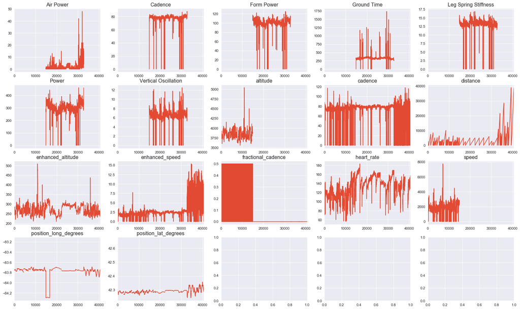

```python
fig, m_axs = plt.subplots(4, 5, figsize=(25, 15))
for c_ax, c_col in zip(m_axs.flatten(), df.select_dtypes(['float']).columns):
    df[c_col].plot(ax=c_ax)
    c_ax.set_title(c_col)
```

With the following code, we spilt the file into two files for analysis: `rdf` (running file) and `cdf` (cycling file), so that we avoid mixing the data observed in the previous plots where it it visually obvious that there are two separate patterns in general.

```python
# Warnings are turned off because indexes are readjusted automatically and we want to visually avoid the warning
warnings.filterwarnings('ignore')
# Create a deepcopy for running only, so that we can filter out the cycling. Then drom fields we identified
# as not useful for running
rdf = copy.deepcopy(df)
rdf = rdf[df['activity_type']=='Running']
rdf = rdf[df['Cadence']!=0]
rdf.reset_index(inplace=True,drop=True)
rdf = rdf.drop(['fractional_cadence','speed','altitude','Cadence'], axis=1)
# Create a deepcopy for cycling only, so that we can filter out the running. Then drop fields we identified
# as not useful for cycling
cdf = copy.deepcopy(df)
cdf = cdf[df['activity_type']=='Cycling']
cdf=cdf[~pd.notnull(df['Cadence'])]
cdf.reset_index(inplace=True,drop=True)
cdf = cdf.drop(['fractional_cadence','speed','altitude','Air Power','Cadence','Form Power','Ground Time','Leg Spring Stiffness','Power','Vertical Oscillation'], axis=1)
```

**Running**: Before analysis, we just want to visually explore both datasets for consistency. Below we can see **the running file**: This file seems very consistent except for geolocation, however those changes are probably an expected change based on location/direction running habits.

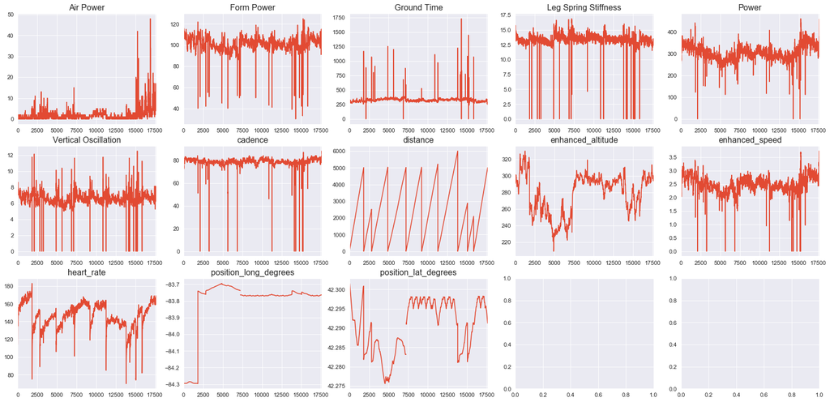

```python
fig, m_axs = plt.subplots(3, 5, figsize=(25, 12))
for c_ax, c_col in zip(m_axs.flatten(), rdf.select_dtypes(['float']).columns):
    rdf[c_col].plot(ax=c_ax)
    c_ax.set_title(c_col)
```

**Cycling**: We want to do the same visual exploration for **the cycling**. There are two particular things to highlight here:

1. `enhanced_speed` and `cadence` seem to show a significant different pattern in the last third of the data. Data seem partially tells me that Client engaged in a more rigorous practice after some point. This is partially corroborated by the latitude and longitude patterns and the distance.
2. Client did not use Heart Rate sensor in a couple of sessions or connected it.

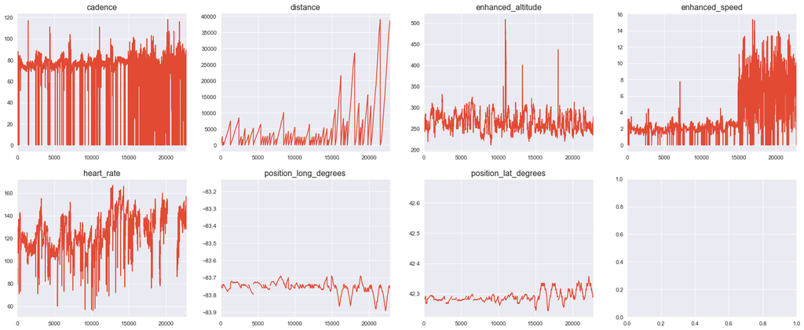

```python
fig, m_axs = plt.subplots(2, 4, figsize=(25, 10))
for c_ax, c_col in zip(m_axs.flatten(), cdf.select_dtypes(['float']).columns):
    cdf[c_col].plot(ax=c_ax)
    c_ax.set_title(c_col)
```

## Visual Analysis

**Total Workout Session Visual**:

The following histogram shows the total time the Client engages in workout. The only recommendation here is that the Client should keep the sessions to a minimum of 15 minutes. There seems to be a progression as the most recent dates, he is able to mantain long sessions more frequently.

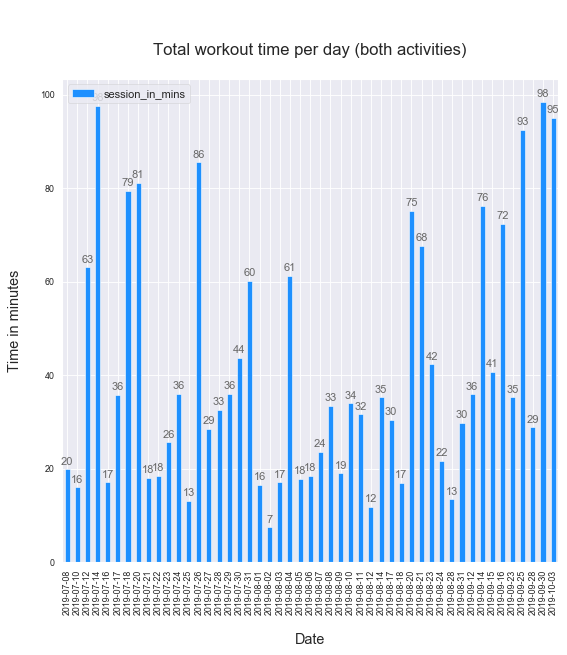

```python
# Creating a df to calculate the total time in each day (adding datafiles if occured the same day)
fmt = '%H:%M:%S'
maxdf=df.groupby(['date','datafile'])[['time']].max()
mindf=df.groupby(['date','datafile'])[['time']].min()
mindf= mindf.rename(columns={'time': 'time_min'})
cdfagg=pd.merge(left=maxdf,right=mindf,how='left', left_index=True, right_index=True)
cdfagg['time'] = pd.to_datetime(cdfagg['time'],format=fmt,errors='coerce')
cdfagg['time_min'] = pd.to_datetime(cdfagg['time_min'],format=fmt,errors='coerce')
cdfagg['session_time']=cdfagg['time']-cdfagg['time_min']
cdfagg['session_in_mins']=cdfagg['session_time'].apply(lambda x: x/np.timedelta64(1,'m'))
cdfagg.reset_index(inplace=True)
cleaned=cdfagg.groupby(['date'])[['session_in_mins']].sum()
# Histogram creation adding total session time to the chart
plt.figure(figsize=(20,20))
chart=cleaned.plot(kind='bar',
                     color='dodgerblue')
chart.set_xticklabels(chart.get_xticklabels(), rotation=90,fontsize=10)
chart.yaxis.set_major_formatter(mpl.ticker.StrMethodFormatter('{x:,.0f}'))
chart.tick_params(labelsize=8)
for p in chart.patches:
    height = p.get_height()
    chart.text(p.get_x()+p.get_width()/2.,
               height + 1,
               '{0:,.0f}'.format(height),
               ha="center",
               color='dimgray')

plt.title('\n\nTotal workout time per day (both activities)\n',fontsize=15)
plt.ylabel("Time in minutes", labelpad=16,fontsize=13)
plt.xlabel("Date", labelpad=16,fontsize=13)
```

**Heart Rate Visual**: This visual shows me that there there are some sessions where the Client engaged in very intense activity. A general good advice for Chris is to try to keep heart rate levels below 175 to maximize the benefit of the session. There is a sessiont that took place in 8/17 that is above 180bpm.

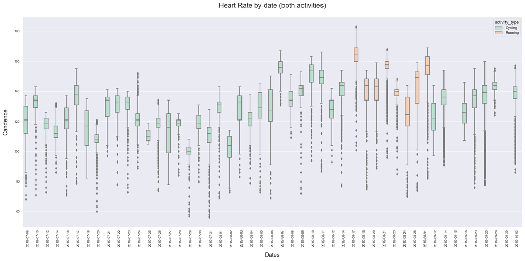

```python
#Here we will use the total dataset to see the heart rate by data for both activities
plt.figure(figsize=(20,10))
chart=sns.boxplot(y='heart_rate', x='date',
                 data=df,
                 hue='activity_type',
                 palette="Pastel2",
                 )

chart.set_xticklabels(chart.get_xticklabels(), rotation=90,fontsize=15)
chart.set_title('Heart Rate by date (both activities)\n',fontsize=19)
chart.yaxis.set_major_formatter(mpl.ticker.StrMethodFormatter('{x:,.0f}'))
chart.set_ylabel("Candence", labelpad=16,fontsize=16)
chart.set_xlabel("Dates", labelpad=16,fontsize=16)
chart.tick_params(labelsize=9)
categories = chart.get_xticks()
lines = chart.get_lines()
chart.figure.tight_layout()
```

**Heart Rate Visual**:

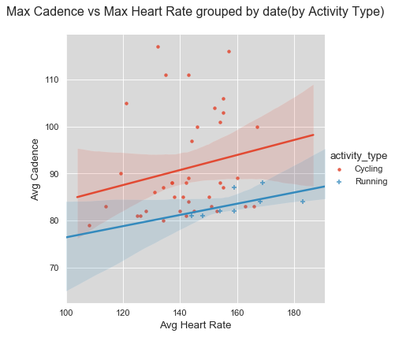

```python
#We first prepate the data to use maximum heart rate and cadence
cdfavgdate=df.groupby(['date','activity_type'])[['heart_rate','cadence']].mean()
cdfmaxdate=df.groupby(['date','activity_type'])[['heart_rate','cadence','distance','time']].max()
cdfmindate=df.groupby(['date','activity_type'])[['time']].min()
cdfmindate = cdfmindate.rename(columns={'time': 'time_min'})
cdfavgdate.reset_index(inplace=True)
cdfmaxdate.reset_index(inplace=True)
#We now plot the relationship between heart rate and cadence for both activities
sns.set_style("darkgrid", {"axes.facecolor": ".85"})    # adding some aethstetics to the plot
sns.lmplot(x="heart_rate",                              # declare the variable on the x axis
            y="cadence",                                # declare the variable on the y axis
            data=cdfmaxdate,                            # dataframre to be used
            hue="activity_type",
            markers=[".","+"]).set(title = 'Max Cadence vs Max Heart Rate grouped by date(by Activity Type)\n',  # Adding additional control over the chart
                            xlabel = 'Avg Heart Rate',
                            ylabel = 'Avg Cadence' );   # control the color of the regression line
```

**Heart Rate Visual**:

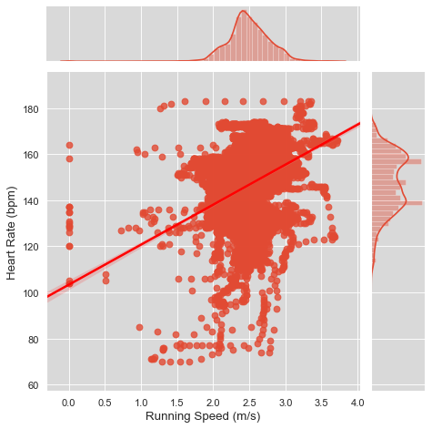

```python
chart=sns.jointplot(x="enhanced_speed",
              y="heart_rate",
              data=rdf,
              kind="reg",
              line_kws={'color': 'red'})

chart.set_axis_labels("Running Speed (m/s)", "Heart Rate (bpm)", fontsize=12)
```

In this visual I wanted to show that for cycling, there is a smoother heart rate to speed relationship. Even at avergae speeds grated than 5.5 m/s, the average heart rates do not go beyond 140. So my recommendation is for the Client to use bicycle more frequently to maximize heart health benefits

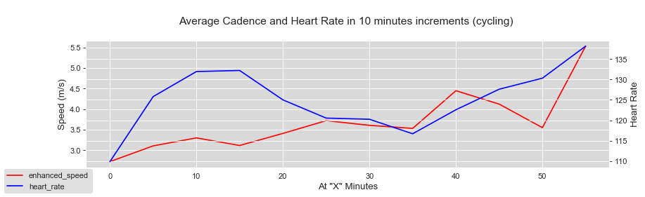

```python
#We first group the timestamp hbased on 10 min increments in a new df
cdf.set_index('timestamp',inplace=True)
c10avg=cdf.groupby(pd.Grouper(freq='600s')).mean()
c10avg = c10avg[c10avg['distance'].notna()]
c10avg.reset_index(inplace=True)
#We then use timestamp to create a new field that will look at 10 minuts increments as a scalar
c10avg['date'] = c10avg['timestamp'].dt.date
c10avg['time'] = c10avg['timestamp'].dt.time
incr=0
l=len(c10avg)
for i, row in c10avg.iterrows():
    c10avg.loc[i,'time_interval']=incr
    if i != l-1:
        if c10avg.loc[i,'date'] == c10avg.loc[i+1,'date']:
            incr=incr+5
        else:
            incr=0
    else:
        incr=incr+5
ts=c10avg.groupby(['time_interval'])[['cadence','heart_rate','enhanced_speed']].mean()
ts.reset_index(inplace=True)
# With the new time series df, we plot heart rate and enhanced speed to see the trend
plt.figure(figsize=(12,3))
plt.plot(ts["time_interval"], ts["enhanced_speed"],'r-', label="enhanced_speed")
plt.gca().set_xlabel("At \"X\" Minutes")
plt.gca().twinx()
plt.plot(ts["time_interval"], ts["heart_rate"],'b-', label="heart_rate")
plt.title("\nAverage Cadence and Heart Rate in 10 minutes increments (cycling) \n", fontsize=14)
plt.gcf().legend(loc=3)
plt.gcf().axes[0].set_ylabel("Speed (m/s)")
plt.gcf().axes[1].set_ylabel("Heart Rate")
```